# Statistics — Complete Interview Notebook

#### Cross-Validation

| Method | Description | Use Case |
| --- | --- | --- |
| **K-Fold** | Split data into k folds, train on k-1, test on 1, rotate | Standard (k=5 or 10) |
| **Stratified K-Fold** | Preserves class proportions in each fold | Imbalanced classification |
| **Leave-One-Out (LOO)** | k = n (each observation is a test set once) | Very small datasets |
| **Time Series Split** | Expanding window, never train on future data | Time-ordered data |
| **Repeated K-Fold** | Repeat k-fold with different random splits | More robust estimate |

```python
from sklearn.model_selection import cross_val_score, StratifiedKFold
from sklearn.linear_model import LogisticRegression

# Stratified 5-fold CV
# model = LogisticRegression()
# cv = StratifiedKFold(n_splits=5, shuffle=True, random_state=42)
# scores = cross_val_score(model, X, y, cv=cv, scoring='accuracy')
# print(f'CV Accuracy: {scores.mean():.3f} ± {scores.std():.3f}')
```

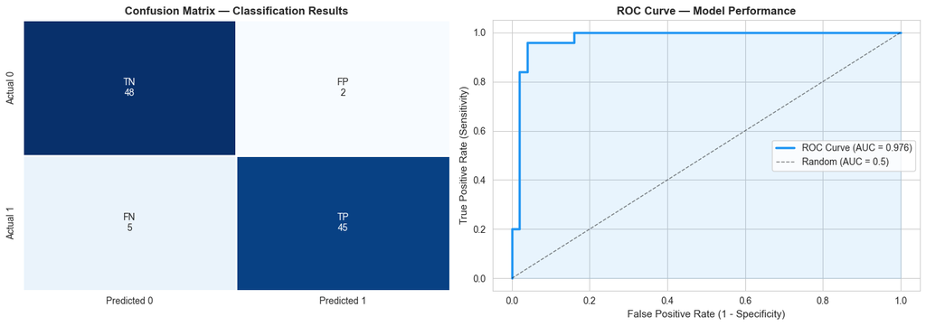

```
Precision: 0.957 | Recall: 0.900 | AUC: 0.976
Interview tip: Use AUC-ROC on balanced data, AUC-PR on imbalanced data!
```

```python
# ──────────────────────────────────────────────
# Classification Evaluation — Confusion Matrix + ROC
# ──────────────────────────────────────────────
import numpy as np
import matplotlib.pyplot as plt
import seaborn as sns
from sklearn.metrics import confusion_matrix, roc_curve, auc

np.random.seed(42)

# Simulated predictions
y_true = np.array([1]*50 + [0]*50)
y_scores = np.concatenate([np.random.beta(5, 2, 50), np.random.beta(2, 5, 50)])
y_pred = (y_scores > 0.5).astype(int)

fig, axes = plt.subplots(1, 2, figsize=(14, 5))

# 1. Confusion Matrix Heatmap
cm = confusion_matrix(y_true, y_pred)
labels = np.array([['TN\n'+str(cm[0,0]), 'FP\n'+str(cm[0,1])],
                   ['FN\n'+str(cm[1,0]), 'TP\n'+str(cm[1,1])]])
sns.heatmap(cm, annot=labels, fmt='', cmap='Blues', ax=axes[0],
            xticklabels=['Predicted 0', 'Predicted 1'],
            yticklabels=['Actual 0', 'Actual 1'],
            cbar=False, linewidths=2, linecolor='white')
axes[0].set_title('Confusion Matrix — Classification Results', fontweight='bold', fontsize=12)

# 2. ROC Curve
fpr, tpr, thresholds = roc_curve(y_true, y_scores)
roc_auc = auc(fpr, tpr)
axes[1].plot(fpr, tpr, color='#2196F3', linewidth=2.5,
             label=f'ROC Curve (AUC = {roc_auc:.3f})')
axes[1].plot([0, 1], [0, 1], 'k--', linewidth=1, alpha=0.5, label='Random (AUC = 0.5)')
axes[1].fill_between(fpr, tpr, alpha=0.1, color='#2196F3')
axes[1].set_xlabel('False Positive Rate (1 - Specificity)', fontsize=11)
axes[1].set_ylabel('True Positive Rate (Sensitivity)', fontsize=11)
axes[1].set_title('ROC Curve — Model Performance', fontweight='bold', fontsize=12)
axes[1].legend(fontsize=10)

plt.tight_layout()
plt.show()

precision = cm[1,1] / (cm[1,1] + cm[0,1])
recall = cm[1,1] / (cm[1,1] + cm[1,0])
print(f'Precision: {precision:.3f} | Recall: {recall:.3f} | AUC: {roc_auc:.3f}')
print('Interview tip: Use AUC-ROC on balanced data, AUC-PR on imbalanced data!')
```

#### Bootstrap Evaluation

1. Sample n observations with replacement from training data
2. Train model on bootstrap sample
3. Evaluate on out-of-bag (OOB) samples (~36.8% of data)
4. Repeat B times → distribution of performance metric
5. Report mean ± std of metric

#### Model Evaluation — Interview Questions

| # | Question | Answer |
| --- | --- | --- |
| 1 | Precision vs Recall — when to prioritize each? | • Precision: minimize false positives (spam filter, fraud alerts) • Recall: minimize false negatives (cancer screening, security threats) • Precision question: 'Of those I flagged, how many were corre… |
| 2 | What is the F1 score and when do you use it? | • Harmonic mean of precision and recall: $2 \cdot P \cdot R / (P+R)$ • Use when: classes are imbalanced AND you care about both P and R • Harmonic mean penalizes extreme differences (P=1, R=0.01 → F1≈… |
| 3 | Why is accuracy misleading for imbalanced data? | • 99% negative class: model predicting all negatives gets 99% accuracy • But catches 0% of positives — useless for fraud detection • Better metrics: precision, recall, F1, AUC, PR-AUC • Always check c… |
| 4 | Explain the ROC curve. | • X-axis: FPR (1−specificity); Y-axis: TPR (recall) • Each point = different classification threshold • Upper-left corner = perfect (high TPR, low FPR) • Diagonal = random; below diagonal = worse than… |
| 5 | AUC-ROC vs PR-AUC: when to use which? | • AUC-ROC: balanced classes, overall model comparison • PR-AUC: imbalanced data (e.g., 1% positive class) • ROC can be overly optimistic with imbalanced data • PR-AUC focuses on positive class perform… |
| 6 | What is cross-validation and why is it important? | • Evaluate model on multiple train-test splits • Reduces variance of performance estimate • K-fold: split into k parts, each serves as test once • Prevents overfitting to a single train-test split |
| 7 | What is data leakage? How do you prevent it? | • Training information leaks into test set → inflated performance • Types: target leakage (future info), train-test contamination • Prevention: split before preprocessing, use pipelines • Example: sca… |
| 8 | What is stratified sampling in cross-validation? | • Preserves class proportions in each fold • Important for imbalanced datasets • Without stratification: a fold might have 0 positive examples • Always use stratified K-fold for classification |
| 9 | How do you choose the threshold for classification? | • Default: 0.5, but not always optimal • Precision-recall tradeoff: lower threshold = higher recall, lower precision • Choose based on business cost: cost of FP vs cost of FN • Methods: F1-optimal thr… |
| 10 | MAE vs RMSE — when to use which? | • MAE: treats all errors equally (robust to outliers) • RMSE: penalizes large errors more (sensitive to outliers) • If large errors are costly: use RMSE (housing prices off by $100K matters more) • RM… |
| 11 | What is the log-loss metric? | • $-\frac{1}{n}\sum[y_i\ln(\hat{p}_i) + (1-y_i)\ln(1-\hat{p}_i)]$ • Penalizes confident wrong predictions heavily • Range: 0 (perfect) to ∞; lower is better • Prefer over accuracy when probabilities m… |
| 12 | What is a calibrated model? | • Predicted probabilities match actual frequencies • P(y=1 &#124; model says 0.7) should actually be ~70% • Check: calibration plot (reliability diagram) • Fix: Platt scaling, isotonic regression |
| 13 | What is the train-validation-test split? | • Train: fit model (60-70%); Validation: tune hyperparameters (15-20%); Test: final evaluation (15-20%) • Never touch test set for tuning — it's only for final reporting • Alternative: K-fold CV on tr… |
| 14 | How do you handle imbalanced classes for evaluation? | • Use appropriate metrics: F1, PR-AUC, macro/weighted averages • Resampling: SMOTE (oversample minority), undersample majority • Class weights: penalize misclassifying minority class more • Evaluation… |
| 15 | What is Cohen's Kappa? | • Agreement beyond chance: $\kappa = \frac{p_o - p_e}{1 - p_e}$ • $p_o$ = observed agreement, $p_e$ = expected by chance • κ = 1: perfect agreement; κ = 0: chance level; κ < 0: worse than chance • Bet… |
| 16 | What is underfitting vs overfitting? | • Underfitting: model too simple — high bias, poor on train AND test • Overfitting: model too complex — low bias, great on train, poor on test • Detection: compare train vs test performance (learning … |
| 17 | What is a learning curve? | • Plot performance vs training set size • Training score starts high and decreases; validation increases • Gap between curves: high gap = overfitting, low gap = underfitting • If both plateau low: und… |
| 18 | How do you evaluate a regression model comprehensively? | • Metrics: R², Adjusted R², RMSE, MAE, MAPE • Residual analysis: plot residuals vs fitted, Q-Q plot • Cross-validation: K-fold CV with RMSE as scoring metric • Check for: normality, heteroscedasticity… |
| 19 | What is information leakage through time? | • Using future data to predict the past • Example: using next month's sales to predict this month • Prevention: time-series split (never train on future) • Special case: feature engineering using futu… |
| 20 | What is the baseline model and why is it important? | • Simplest possible model: predict mean (regression) or majority class (classification) • Benchmark: any model must beat the baseline to be useful • Random baseline for classification: 1/k accuracy fo… |
| 21 | Explain macro, micro, and weighted averaging for multiclass. | • Micro: pool all TP, FP, FN across classes → single metric • Macro: compute metric per class, take unweighted average • Weighted: compute per class, weight by class frequency • Macro treats all class… |
| 22 | What is the Brier score? | • MSE for probability predictions: $\frac{1}{n}\sum(y_i - \hat{p}_i)^2$ • Range: 0 (perfect) to 1 (worst); lower is better • Captures both discrimination and calibration • Decomposition: reliability +… |
| 23 | What is nested cross-validation? | • Outer loop: K-fold for model evaluation • Inner loop: K-fold for hyperparameter tuning (within each outer fold) • Prevents bias from tuning on the same data used for evaluation • Gives unbiased esti… |
| 24 | How do you compare two models statistically? | • Paired t-test on fold-level CV scores (5×2 CV paired t-test) • McNemar's test: compare errors on same test set • Bayesian comparison: posterior probability one model is better • Don't just compare s… |
| 25 | What is MAPE and when does it fail? | • Mean Absolute Percentage Error: $\frac{1}{n}\sum\vert y_i-\hat{y}_i\vert /\vert y_i\vert $ • Scale-independent — compare across different magnitudes • Fails when: true values near zero (division by … |

### Part 11: Bayesian Statistics

Bayesian statistics provides a framework for **updating beliefs with data**. Unlike frequentist methods, it treats parameters as random variables with distributions.

#### Bayesian vs Frequentist

|  | Frequentist | Bayesian |
| --- | --- | --- |
| **Parameters** | Fixed but unknown | Random variables with distributions |
| **Probability** | Long-run frequency | Degree of belief |
| **Data** | Random (sampling variability) | Fixed (what you observed) |
| **Inference** | p-values, confidence intervals | Posterior distributions, credible intervals |
| **Prior info** | Not used in analysis | Explicitly incorporated via prior |
| **Result** | Point estimate + CI | Full probability distribution of parameter |

#### Bayes' Theorem (Revisited)

$$P(\theta \mid \text{data}) = \frac{P(\text{data} \mid \theta) \cdot P(\theta)}{P(\text{data})}$$

$$\text{Posterior} \propto \text{Likelihood} \times \text{Prior}$$

| Component | Symbol | Meaning | Example |
| --- | --- | --- | --- |
| **Prior** | $P(\theta)$ | Belief before seeing data | Click rate is probably between 2-8% |
| **Likelihood** | $P(\text{data}\mid \theta)$ | How likely is this data given θ | P(50 clicks in 1000 views \| θ) |
| **Posterior** | $P(\theta\mid \text{data})$ | Updated belief after seeing data | Click rate is between 3.5-6.5% |
| **Evidence** | $P(\text{data})$ | Normalizing constant | Often computed via integration |

#### Prior Distributions

| Prior Type | Description | Example |
| --- | --- | --- |
| **Non-informative / Flat** | No prior knowledge | Uniform(0, 1) for a proportion |
| **Weakly informative** | Vague but constraining | Normal(0, 10) for a coefficient |
| **Informative** | Strong prior knowledge | Beta(80, 920) if historical CTR ≈ 8% |
| **Conjugate** | Prior and posterior are same family | Beta prior + Binomial likelihood → Beta posterior |

**Common Conjugate Pairs:**

| Likelihood | Conjugate Prior | Posterior |
| --- | --- | --- |
| Binomial | Beta(α, β) | Beta(α + successes, β + failures) |
| Poisson | Gamma(α, β) | Gamma(α + Σx, β + n) |
| Normal (known σ) | Normal(μ₀, σ₀²) | Normal(updated mean, updated var) |
| Exponential | Gamma(α, β) | Gamma(α + n, β + Σx) |

#### Bayesian Updating Example

**Scenario:** You're estimating a website's click-through rate (CTR).

```python
import numpy as np
from scipy import stats

# Prior: Beta(2, 18) — believe CTR is around 10% (weakly)
alpha_prior, beta_prior = 2, 18

# Data: 15 clicks out of 200 impressions
clicks, impressions = 15, 200

# Posterior: Beta(alpha_prior + clicks, beta_prior + non_clicks)
alpha_post = alpha_prior + clicks  # 17
beta_post = beta_prior + (impressions - clicks)  # 203

posterior = stats.beta(alpha_post, beta_post)

print(f'Prior mean:     {alpha_prior/(alpha_prior+beta_prior):.4f}')
print(f'MLE (data only): {clicks/impressions:.4f}')
print(f'Posterior mean: {posterior.mean():.4f}')  # weighted blend of prior and data
print(f'95% Credible Interval: ({posterior.ppf(0.025):.4f}, {posterior.ppf(0.975):.4f})')

# With more data, prior matters less
clicks2, impressions2 = 150, 2000
post2 = stats.beta(alpha_prior + clicks2, beta_prior + impressions2 - clicks2)
print(f'\nWith 10x more data:')
print(f'Posterior mean: {post2.mean():.4f}')  # much closer to MLE
print(f'95% CI: ({post2.ppf(0.025):.4f}, {post2.ppf(0.975):.4f})')  # much narrower
```

```
Prior mean:     0.1000
MLE (data only): 0.0750
Posterior mean: 0.0773
95% Credible Interval: (0.0459, 0.1159)

With 10x more data:
Posterior mean: 0.0752
95% CI: (0.0642, 0.0871)
```

#### Credible Intervals vs Confidence Intervals

|  | Credible Interval (Bayesian) | Confidence Interval (Frequentist) |
| --- | --- | --- |
| **Interpretation** | 95% probability θ is in this interval | 95% of such intervals contain θ |
| **Intuitive?** | ✅ Yes — directly about the parameter | ❌ No — about the procedure |
| **Requires** | Prior distribution | Only data |
| **Different with same data?** | Depends on prior | Always the same |

#### Bayesian A/B Testing

```python
# Bayesian A/B test: which version has higher CTR?
# Version A: 120 clicks / 1000 impressions
# Version B: 145 clicks / 1000 impressions

# Flat prior: Beta(1, 1)
posterior_a = stats.beta(1 + 120, 1 + 880)  # Beta(121, 881)
posterior_b = stats.beta(1 + 145, 1 + 855)  # Beta(146, 856)

# P(B > A) via simulation
n_samples = 100_000
samples_a = posterior_a.rvs(n_samples)
samples_b = posterior_b.rvs(n_samples)
prob_b_better = np.mean(samples_b > samples_a)
expected_lift = np.mean((samples_b - samples_a) / samples_a)

print(f'P(B > A) = {prob_b_better:.3f}')     # e.g., 0.94
print(f'Expected lift: {expected_lift:.1%}')   # e.g., 21%
print(f'Risk (max loss if choosing B): {np.percentile(samples_a - samples_b, 95):.4f}')
```

```
P(B > A) = 0.950
Expected lift: 21.6%
Risk (max loss if choosing B): -0.0000
```

#### MCMC (Markov Chain Monte Carlo)

When posteriors can't be computed analytically, use MCMC to sample from them.

| Algorithm | Description | Speed |
| --- | --- | --- |
| **Metropolis-Hastings** | Accept/reject proposed samples | Slow |
| **Gibbs Sampling** | Sample each parameter conditionally | Medium |
| **Hamiltonian MC (HMC)** | Uses gradients for efficient exploration | Fast |
| **NUTS** | Auto-tuned HMC (PyMC, Stan default) | Fastest |

#### Bayesian Statistics — Interview Questions

| # | Question | Answer |
| --- | --- | --- |
| 1 | Explain Bayesian vs Frequentist statistics. | • Frequentist: parameters are fixed; probability = long-run frequency • Bayesian: parameters have distributions; probability = degree of belief • Bayesian uses prior information; Frequentist doesn't •… |
| 2 | What is a prior? How do you choose one? | • Prior: initial belief about parameter before seeing data • Non-informative: Uniform or flat — let data speak • Informative: from domain knowledge or previous studies • Conjugate: mathematically conv… |
| 3 | What is a conjugate prior? Why is it useful? | • Conjugate: prior and posterior belong to same distribution family • Beta-Binomial, Gamma-Poisson, Normal-Normal • Benefit: closed-form posterior (no MCMC needed) • Example: Beta(α,β) + k successes →… |
| 4 | What is a credible interval? How is it different from a confidence interval? | • Credible: 95% probability parameter is in this interval (given data + prior) • Confidence: 95% of such intervals from repeated sampling contain the true value • Credible is more intuitive and direct… |
| 5 | Explain Bayesian A/B testing. What are its advantages? | • Model each variant with Beta posterior • Compute P(B > A) via simulation — direct probability answer • Advantages: no minimum sample size, any-time valid, intuitive results • Report: P(B better), ex… |
| 6 | What is MCMC? When do you need it? | • Markov Chain Monte Carlo: sample from posterior when no closed form • Needed for: complex models, many parameters, non-conjugate priors • Generates correlated samples that converge to posterior • To… |
| 7 | How does the prior affect the posterior? | • Informative prior: strong effect, especially with small data • Flat prior: posterior ≈ likelihood (data-driven) • With more data: prior effect diminishes (likelihood dominates) • Sensitivity analysi… |
| 8 | What is the posterior predictive distribution? | • P(new data &#124; observed data) — prediction accounting for parameter uncertainty • Integrates over all possible parameter values weighted by posterior • Gives wider prediction intervals than point… |
| 9 | What is empirical Bayes? | • Estimate prior from the data itself (instead of specifying it) • Not fully Bayesian (prior should be independent of data) • But practical and widely used (James-Stein, shrinkage) • Example: estimate… |
| 10 | What is the Bayes factor? | • $BF = P(\text{data}\mid M_1) / P(\text{data}\mid M_2)$ — evidence ratio for two models • BF > 3: moderate evidence; BF > 10: strong; BF > 100: decisive • Bayesian alternative to p-values for hypothe… |
| 11 | What is MAP estimation? | • Maximum A Posteriori: mode of the posterior distribution • MAP = MLE when prior is flat (uniform) • MAP with Gaussian prior = Ridge regression • MAP with Laplace prior = Lasso regression |
| 12 | What is the difference between MAP and full Bayesian inference? | • MAP: single point estimate (mode of posterior) • Full Bayesian: entire posterior distribution (mean, median, credible interval) • MAP ignores uncertainty; full Bayesian quantifies it • Full Bayesian… |
| 13 | What is a hierarchical Bayesian model? | • Multi-level model: parameters have their own distributions with hyperparameters • Example: each store has its own conversion rate, but rates share a common distribution • Partial pooling: borrows st… |
| 14 | Explain the concept of shrinkage in Bayesian estimation. | • Individual estimates pulled toward the group mean • Groups with less data are pulled more (borrow strength from others) • Reduces overfitting and extreme estimates • James-Stein: shrinkage estimator… |
| 15 | What is a non-informative prior? | • Prior that contributes minimal information: Uniform, Jeffreys • Goal: let data drive the posterior • Jeffreys prior: $p(\theta) \propto \sqrt{I(\theta)}$ (Fisher information) • Not always truly non-… |
| 16 | When would you use Bayesian methods over Frequentist? | • Small sample sizes (prior helps stabilize estimates) • Need probability of hypothesis (not just p-value) • Sequential testing / early stopping (A/B tests) • Complex hierarchical models (multi-level … |
| 17 | What is the evidence (marginal likelihood)? | • $P(\text{data}) = \int P(\text{data}\mid \theta) P(\theta) d\theta$ • Normalizing constant in Bayes' theorem • Used for model comparison (Bayes factor = ratio of evidences) • Often intractable → app… |
| 18 | What is variational inference? | • Approximate posterior with simpler distribution (e.g., Gaussian) • Minimize KL divergence between approximation and true posterior • Much faster than MCMC for large-scale problems • Used in: variati… |
| 19 | How do you diagnose MCMC convergence? | • Trace plot: chains should look like 'hairy caterpillars' (well-mixed) • R-hat (Gelman-Rubin) ≤ 1.01: chains have converged • Effective sample size (ESS): enough independent samples • Discard burn-in… |
| 20 | Give a real-world example where Bayesian is clearly better. | • Clinical trial with rare disease: only 20 patients available • Frequentist: not enough power, inconclusive p-value • Bayesian: incorporate prior knowledge from similar studies • Result: posterior pr… |

### Part 12: Data Exploration & Preparation

Data preparation often consumes 60-80% of a data scientist's time. Good preparation is the difference between a model that works and one that doesn't.

#### Outlier Detection Methods

| Method | Formula / Approach | Best For |
| --- | --- | --- |
| **Z-score** | $z = (x - \mu)/\sigma$; outlier if $\vert z\vert > 3$ | Normal distribution |
| **Modified Z-score** | Uses median and MAD instead | Robust, non-normal |
| **IQR method** | Below $Q1 - 1.5 \cdot IQR$ or above $Q3 + 1.5 \cdot IQR$ | General purpose, robust |
| **DBSCAN** | Density-based clustering | Multivariate outliers |
| **Isolation Forest** | Tree-based anomaly detection | High-dimensional data |
| **Local Outlier Factor** | Compare local density to neighbors | Varying density |

```python
import numpy as np
from scipy import stats

data = np.array([10, 12, 14, 15, 16, 18, 20, 22, 100])  # 100 is outlier

# Z-score method
z_scores = np.abs(stats.zscore(data))
outliers_z = data[z_scores > 2]  # using threshold 2 for small dataset
print(f'Z-score outliers: {outliers_z}')

# IQR method
q1, q3 = np.percentile(data, [25, 75])
iqr = q3 - q1
lower, upper = q1 - 1.5*iqr, q3 + 1.5*iqr
outliers_iqr = data[(data < lower) | (data > upper)]
print(f'IQR outliers: {outliers_iqr}')

# Isolation Forest
from sklearn.ensemble import IsolationForest
clf = IsolationForest(contamination=0.1, random_state=42)
preds = clf.fit_predict(data.reshape(-1, 1))
print(f'Isolation Forest outliers: {data[preds == -1]}')
```

```
Z-score outliers: [100]
IQR outliers: [100]
Isolation Forest outliers: [100]
```

#### Handling Outliers

| Approach | When to Use |
| --- | --- |
| **Remove** | Data entry error, measurement malfunction |
| **Cap / Winsorize** | Replace extremes with percentile values (e.g., 1st/99th) |
| **Transform** | Log, sqrt to reduce impact (right-skewed data) |
| **Separate model** | Outliers are a distinct population (fraud vs normal) |
| **Robust methods** | Use median, MAD, robust regression |
| **Keep** | If the outlier is a valid, important observation |

#### Missing Data

| Missing Type | Description | Example | Approach |
| --- | --- | --- | --- |
| **MCAR** | Missing Completely At Random | Survey Form lost in mail | Any imputation, deletion OK |
| **MAR** | Missing At Random (given observed data) | Men less likely to answer weight | Model-based imputation |
| **MNAR** | Missing Not At Random | High earners skip income question | Specialized models, sensitivity analysis |

**Imputation Strategies:**

| Method | How | Pros | Cons |
| --- | --- | --- | --- |
| **Mean/Median** | Replace with column mean or median | Simple, fast | Reduces variance, ignores relationships |
| **Mode** | Replace with most frequent value | Categorical data | Can distort distribution |
| **KNN imputation** | Impute from k nearest neighbors | Captures relationships | Slow for large datasets |
| **MICE** | Multiple Imputation by Chained Equations | Handles uncertainty | Complex, requires model specification |
| **Regression** | Predict missing from other features | Uses relationships | Can overfit |
| **Indicator variable** | Add is_missing flag + impute | Preserves missingness info | Doubles features |
| **Drop** | Remove rows or columns | Simple | Loses data; biased if not MCAR |

```python
import pandas as pd
from sklearn.impute import SimpleImputer, KNNImputer

df = pd.DataFrame({
    'age': [25, 30, np.nan, 35, 40, np.nan, 28],
    'income': [50000, 60000, 55000, np.nan, 80000, 65000, np.nan],
    'city': ['NYC', 'LA', 'NYC', 'LA', np.nan, 'NYC', 'LA']
})

# Check missing
print(df.isnull().sum())
print(f'Missing %: {df.isnull().mean() * 100}')

# Mean imputation
imputer_mean = SimpleImputer(strategy='mean')
df[['age', 'income']] = imputer_mean.fit_transform(df[['age', 'income']])

# KNN imputation (considers relationships between features)
# knn_imp = KNNImputer(n_neighbors=3)
# df_imputed = knn_imp.fit_transform(df[['age', 'income']])
```

```
age       2
income    2
city      1
dtype: int64
Missing %: age       28.571429
income    28.571429
city      14.285714
dtype: float64
```

#### Feature Scaling

| Method | Formula | Range | When to Use |
| --- | --- | --- | --- |
| **Standardization (Z-score)** | $z = (x - \mu) / \sigma$ | (-∞, +∞), mean=0, std=1 | Most ML algorithms, normally distributed |
| **Min-Max** | $(x - x_{min}) / (x_{max} - x_{min})$ | [0, 1] | Neural networks, distance-based |
| **Robust Scaler** | $(x - \text{median}) / IQR$ | (-∞, +∞) | When outliers present |
| **Log Transform** | $\ln(x)$ or $\ln(x + 1)$ | (0, +∞) | Right-skewed data |
| **Box-Cox** | Automated power transform | (-∞, +∞) | Normalize any positive data |

```python
from sklearn.preprocessing import StandardScaler, MinMaxScaler, RobustScaler

data = np.array([[100, 10000], [200, 20000], [150, 15000], [300, 50000]])

# Standardization
scaler_z = StandardScaler()
print(f'StandardScaler:\n{scaler_z.fit_transform(data)}')

# Min-Max
scaler_mm = MinMaxScaler()
print(f'MinMaxScaler:\n{scaler_mm.fit_transform(data)}')

# Robust (resistant to outliers)
scaler_r = RobustScaler()
print(f'RobustScaler:\n{scaler_r.fit_transform(data)}')
```

```
StandardScaler:
[[-1.18321596 -0.88354126]
 [ 0.16903085 -0.2409658 ]
 [-0.50709255 -0.56225353]
 [ 1.52127766  1.68676059]]
MinMaxScaler:
[[0.    0.   ]
 [0.5   0.25 ]
 [0.25  0.125]
 [1.    1.   ]]
RobustScaler:
[[-0.85714286 -0.54545455]
 [ 0.28571429  0.18181818]
 [-0.28571429 -0.18181818]
 [ 1.42857143  2.36363636]]
```

> **Important:** Always fit scaler on training data only, then transform both train and test. Never fit on the entire dataset (data leakage).

#### Feature Selection

| Method | Type | Description |
| --- | --- | --- |
| **Correlation filter** | Filter | Remove features with low correlation to target |
| **Variance threshold** | Filter | Remove near-constant features |
| **Chi-square** | Filter | Test independence of categorical features with target |
| **Mutual Information** | Filter | Non-linear dependency measure |
| **Lasso (L1)** | Embedded | Zero out irrelevant features |
| **Tree importance** | Embedded | Feature importance from Random Forest / XGBoost |
| **RFE** | Wrapper | Recursively remove least important features |
| **Forward/Backward** | Wrapper | Add/remove features based on model performance |

#### Data Cleaning Checklist

1. **Duplicates**: `df.drop_duplicates()` — check for near-duplicates too
2. **Data types**: ensure numeric columns aren't stored as strings
3. **Invalid values**: negative ages, future dates, impossible combinations
4. **Consistency**: date formats, currency, units, encoding
5. **Missing data**: identify mechanism (MCAR/MAR/MNAR), impute or drop
6. **Outliers**: investigate, decide whether to keep, cap, or transform
7. **Cardinality**: handle high-cardinality categoricals (frequency encoding, target encoding)

#### Data Exploration & Preparation — Interview Questions

| # | Question | Answer |
| --- | --- | --- |
| 1 | How do you detect outliers? Compare several methods. | • Z-score: simple but assumes normality; threshold at $\vert z\vert $ > 3 • IQR: robust, non-parametric; threshold at 1.5 × IQR beyond Q1/Q3 • Isolation Forest: ML-based, handles multivariate outliers… |
| 2 | Should you always remove outliers? | • NO — depends on context • Remove: data entry errors, sensor malfunctions • Keep: genuine extreme values (luxury home prices, celebrity incomes) • Transform: log/sqrt to reduce impact while preservin… |
| 3 | Explain MCAR, MAR, MNAR with examples. | • MCAR: missingness unrelated to any variable (random survey loss) • MAR: missingness depends on observed data (younger people skip income) • MNAR: missingness depends on missing value itself (high ea… |
| 4 | When would you use KNN imputation vs mean imputation? | • Mean: fast, simple but ignores variable relationships • KNN: considers relationships — imputes based on similar rows • KNN better when: features are correlated, data is MAR • Mean acceptable when: f… |
| 5 | What is MICE imputation? | • Multiple Imputation by Chained Equations • Iteratively imputes each variable using regression on the others • Creates multiple imputed datasets → pool results • Captures uncertainty about imputed va… |
| 6 | When should you standardize vs normalize features? | • Standardize (z-score): algorithms using distances (KNN, SVM), gradient-based (neural nets, logistic) • Min-Max: bounded data, neural networks (output in [0,1]) • Robust: when outliers are present • … |
| 7 | What is the curse of dimensionality? | • As dimensions increase: data becomes sparse, distances become meaningless • Fixed n: adding features makes distance-based methods worse • Need exponentially more data as dimensions grow • Fix: featu… |
| 8 | How do you handle categorical variables? | • Ordinal: label encoding (low=1, medium=2, high=3) • Nominal (few levels): one-hot encoding • Nominal (many levels): target encoding, frequency encoding • Text: TF-IDF, embeddings |
| 9 | What is feature engineering? Give examples. | • Creating new features from existing ones • Date → day of week, month, is_weekend • Text → word count, sentiment score • Numerical → binning, log transform, polynomial features • Domain-specific: BMI… |
| 10 | How do you handle class imbalance? | • Resampling: oversample minority (SMOTE), undersample majority • Class weights: penalize misclassifying minority more • Metrics: use F1, PR-AUC instead of accuracy • Threshold tuning: lower classific… |
| 11 | What is target encoding for categorical variables? | • Replace category with average of target for that category • Captures relationship between category and target • Risk: overfitting, especially with rare categories • Mitigation: use with cross-valida… |
| 12 | What is data leakage and how do you prevent it in preprocessing? | • Using test information during training • Fit scalers/imputers on training data ONLY, then transform test • Time-series: never use future data • Use sklearn Pipeline to prevent errors |
| 13 | When do you drop a feature vs impute missing values? | • Drop if: > 50-70% missing AND doesn't add value • Impute if: < 30% missing, feature is important • Create indicator: add 'is_missing' flag before imputing • Always consider: what does missingness me… |
| 14 | What is Winsorizing? | • Cap extreme values at a specified percentile • Example: replace all values below 1st percentile and above 99th percentile • Preserves data size (unlike removal) • Reduces outlier influence while kee… |
| 15 | Explain the Box-Cox transformation. | • Find optimal power λ to make data most normal • $y(\lambda) = (x^\lambda - 1)/\lambda$ if λ ≠ 0; $\ln(x)$ if λ = 0 • Only works for positive data • Yeo-Johnson: generalized Box-Cox that handles zero… |
| 16 | What is one-hot encoding? When is it a problem? | • Create binary column for each category: color → is_red, is_blue, is_green • Problem: high cardinality → too many features (1000 categories = 1000 columns) • Problem: dummy variable trap (use k-1 dum… |
| 17 | How do you handle duplicates in a dataset? | • Exact duplicates: drop with `df.drop_duplicates()` • Near-duplicates: fuzzy matching (Levenshtein distance, Jaccard similarity) • Investigate: are duplicates data errors or legitimate? (same person,… |
| 18 | What is data imputation bias? | • Imputation can introduce systematic bias if method is wrong • Mean imputation: reduces variance, dilutes relationships • If data is MNAR: any imputation will be biased • Multiple imputation (MICE) p… |
| 19 | How do you verify data quality? | • Completeness: check null counts per column • Uniqueness: check for duplicates • Validity: assert constraints (age > 0, date < today) • Consistency: same entity, same values across sources • Timeline… |
| 20 | What is Simpson's Paradox and how does it relate to data preparation? | • Trend reverses when data is disaggregated by a confounding group • Example: Drug A looks better overall, but Drug B is better within each age group • Relates to: proper segmentation, controlling con… |
| 21 | When should you use log transformation? | • Right-skewed data (income, prices, counts) • Multiplicative relationships (compound growth) • To stabilize variance (variance proportional to mean) • Not for: data with zeros or negatives (use log(x… |
| 22 | What is the variance threshold for feature selection? | • Remove features with near-zero variance (constant or nearly constant) • `VarianceThreshold(threshold=0.01)` — removes features with var < 0.01 • Binary features: threshold = 0.8*(1-0.8) removes feat… |
| 23 | How do you handle mixed data types in a dataset? | • Separate numeric and categorical preprocessing paths • sklearn ColumnTransformer: apply different transforms to different columns • Encode categoricals, scale numericals, impute separately • Use Pip… |
| 24 | What is mutual information for feature selection? | • Measures how much knowing X reduces uncertainty about Y • MI = 0: independent; MI > 0: informative • Works for linear AND non-linear relationships (unlike correlation) • `sklearn.feature_selection.m… |
| 25 | Walk through your complete data preparation pipeline. | • 1. Load and explore (shape, dtypes, head, describe) • 2. Handle missing data (investigate mechanism, impute or drop) • 3. Remove/handle outliers (IQR, z-score, domain knowledge) • 4. Encode categori… |

### Part 13: Simulation & Optimization

Simulation methods let you solve problems that are analytically intractable. Optimization finds the best solution under constraints.

#### Monte Carlo Simulation

Use random sampling to estimate quantities that are difficult to compute exactly.

**Steps:**

1. Define the model and its random inputs
2. Generate many random samples (10,000+)
3. Run the model for each sample
4. Analyze the distribution of results

```python
import numpy as np

# Estimate pi using Monte Carlo
n = 1_000_000
x = np.random.uniform(-1, 1, n)
y = np.random.uniform(-1, 1, n)
inside_circle = (x**2 + y**2) <= 1
pi_estimate = 4 * np.sum(inside_circle) / n
print(f'Pi estimate: {pi_estimate:.4f}')  # ≈ 3.1416

# Monte Carlo for business: estimate revenue uncertainty
n_simulations = 10_000
price = np.random.normal(50, 5, n_simulations)       # uncertain price
quantity = np.random.poisson(100, n_simulations)       # uncertain demand
cost = np.random.normal(30, 3, n_simulations)          # uncertain cost
profit = (price - cost) * quantity

print(f'Expected profit: ${np.mean(profit):,.0f}')
print(f'95% CI: (${np.percentile(profit, 2.5):,.0f}, ${np.percentile(profit, 97.5):,.0f})')
print(f'P(loss): {np.mean(profit < 0):.1%}')
```

```
Pi estimate: 3.1420
Expected profit: $1,998
95% CI: ($836, $3,256)
P(loss): 0.1%
```

#### Risk Modeling

| Metric | Formula | Use |
| --- | --- | --- |
| **VaR (Value at Risk)** | Percentile of loss distribution | Maximum loss at confidence level |
| **CVaR / ES** | Mean of losses beyond VaR | Expected loss in worst-case tail |
| **Sharpe Ratio** | $(R_p - R_f) / \sigma_p$ | Risk-adjusted return |

```python
# Value at Risk (VaR) simulation
portfolio_returns = np.random.normal(0.001, 0.02, 10_000)  # daily returns
var_95 = np.percentile(portfolio_returns, 5)  # 5th percentile = 95% VaR
cvar_95 = np.mean(portfolio_returns[portfolio_returns <= var_95])  # tail mean

print(f'95% VaR: {var_95:.4f} ({var_95*100:.2f}% daily loss)')
print(f'95% CVaR: {cvar_95:.4f} (expected loss in worst 5%)')
```

```
95% VaR: -0.0316 (-3.16% daily loss)
95% CVaR: -0.0404 (expected loss in worst 5%)
```

#### Random Variable Simulation

| Method | Description | Use Case |
| --- | --- | --- |
| **Inverse Transform** | Apply $F^{-1}(U)$ where $U \sim \text{Uniform}(0,1)$ | When CDF inverse is known |
| **Acceptance-Rejection** | Propose samples, accept with probability | When direct sampling is hard |
| **Box-Muller** | Generate normals from uniforms | Fast normal generation |

#### Optimization

| Type | Description | Example |
| --- | --- | --- |
| **Linear Programming (LP)** | Objective and constraints are linear | Maximize profit subject to resource limits |
| **Integer Programming** | LP with integer decision variables | Assign workers to shifts |
| **Convex Optimization** | Convex objective, convex constraints | Ridge regression, SVM |
| **Gradient Descent** | Iteratively minimize via gradients | Neural network training |
| **Stochastic GD** | Mini-batch gradient descent | Large-scale ML |

```python
from scipy.optimize import linprog, minimize

# Linear Programming: Maximize 3x + 5y subject to:
# x + 2y <= 14, 3x + y <= 14, x,y >= 0
# linprog minimizes, so negate objective
c = [-3, -5]  # minimize -3x - 5y = maximize 3x + 5y
A_ub = [[1, 2], [3, 1]]
b_ub = [14, 14]
bounds = [(0, None), (0, None)]
result = linprog(c, A_ub=A_ub, b_ub=b_ub, bounds=bounds)
print(f'Optimal: x={result.x[0]:.1f}, y={result.x[1]:.1f}, max value={-result.fun:.1f}')

# Gradient Descent for simple function
def f(x): return (x - 3)**2 + 5  # minimum at x=3
def df(x): return 2 * (x - 3)

x = 0  # starting point
lr = 0.1
for i in range(50):
    x = x - lr * df(x)
print(f'Gradient descent: x={x:.4f}, f(x)={f(x):.4f}')  # x ≈ 3.0
```

```
Optimal: x=2.8, y=5.6, max value=36.4
Gradient descent: x=3.0000, f(x)=5.0000
```

#### Simulation & Optimization — Interview Questions

| # | Question | Answer |
| --- | --- | --- |
| 1 | What is Monte Carlo simulation? When do you use it? | • Use random sampling to estimate quantities or model uncertainty • When: analytical solution is intractable, many random variables • Example: project risk, portfolio VaR, option pricing • More sample… |
| 2 | How accurate is a Monte Carlo estimate? | • Standard error ∝ $1/\sqrt{n}$ — 10x accuracy needs 100x samples • Variance reduction: antithetic variates, importance sampling • 10,000 samples usually gives ~1% accuracy • Trade-off: accuracy vs co… |
| 3 | Explain Value at Risk (VaR). | • Maximum expected loss over a period at a confidence level • 95% daily VaR = $1M means 5% chance of losing > $1M in a day • Methods: historical, parametric (assume normal), Monte Carlo • Limitation: … |
| 4 | What is CVaR / Expected Shortfall? | • Expected loss given that loss exceeds VaR • CVaR = mean of losses in the worst tail (beyond VaR) • More informative than VaR for tail risk • Sub-additive: portfolio CVaR ≤ sum of individual CVaRs |
| 5 | What is gradient descent? | • Iteratively move toward minimum of a function • $x_{t+1} = x_t - \eta \nabla f(x_t)$ where η = learning rate • Variants: batch, stochastic (SGD), mini-batch, Adam • Challenges: local minima, learnin… |
| 6 | Explain linear programming with an example. | • Optimize linear objective subject to linear constraints • Example: maximize profit = 3x + 5y with resource constraints • Solutions always at a vertex of the feasible region • Algorithms: Simplex (ve… |
| 7 | What is the difference between convex and non-convex optimization? | • Convex: any local minimum IS the global minimum — guaranteed optimal • Non-convex: multiple local minima — may get stuck • Most ML: loss functions are convex (linear, logistic regression) • Neural n… |
| 8 | How would you simulate a queue system? | • Define: arrival rate (Poisson), service time (exponential), number of servers • Simulate events: arrivals, service starts, departures • Track: wait times, queue lengths, utilization • M/M/1 queue: a… |
| 9 | What is the bootstrap vs Monte Carlo? | • Bootstrap: resample FROM your data (no assumptions about distribution) • Monte Carlo: sample from ASSUMED distribution (parametric model) • Bootstrap: non-parametric, empirical distribution • Monte … |
| 10 | What is inverse transform sampling? | • Generate any distribution from Uniform(0,1) • Steps: u ~ U(0,1), x = F⁻¹(u) where F is CDF • Works when CDF inverse is known analytically • Example: Exponential: x = -ln(1-u)/λ |
| 11 | Explain the Simplex algorithm. | • Solves LP by moving along vertices of feasible region • Start at a vertex, move to adjacent vertex with better objective • Stops when no improving vertex exists (optimal found) • Usually efficient (… |
| 12 | What is sensitivity analysis in simulation? | • Vary input parameters to see how output changes • Identify: which inputs have most impact on results? • One-at-a-time vs global sensitivity (Sobol indices) • Helps focus data collection on most infl… |
| 13 | How do you validate a simulation model? | • Compare to real data (backtesting) • Face validity: experts agree it makes sense • Sensitivity: results respond correctly to input changes • Cross-validation: hold out data, compare predicted vs act… |
| 14 | What is importance sampling? | • Variance reduction technique for Monte Carlo • Sample more from important regions of the distribution • Weight samples to correct for biased sampling • Used when: rare events, tail probabilities |
| 15 | What is stochastic gradient descent and why is it preferred? | • Use random mini-batch instead of full dataset per iteration • Much faster per iteration; scales to huge datasets • Noisy updates can escape local minima • Variants: Adam (adaptive learning rates), R… |

### Part 14: Multivariate & Advanced Topics

Advanced statistical techniques for high-dimensional data and complex relationships.

#### Principal Component Analysis (PCA)

PCA reduces dimensionality by finding **orthogonal directions** (principal components) that capture maximum variance.

**Algorithm:**

1. Standardize the data (mean=0, std=1)
2. Compute covariance matrix
3. Find eigenvectors (directions) and eigenvalues (variance explained)
4. Sort by eigenvalue descending
5. Project data onto top k eigenvectors

```python
import numpy as np
from sklearn.decomposition import PCA
from sklearn.preprocessing import StandardScaler

# Generate 5-dimensional correlated data
np.random.seed(42)
n = 200
X = np.random.randn(n, 5)
X[:, 1] = X[:, 0] * 0.8 + np.random.randn(n) * 0.3  # correlated
X[:, 2] = X[:, 0] * 0.6 + np.random.randn(n) * 0.5  # correlated

# Standardize
X_scaled = StandardScaler().fit_transform(X)

# PCA
pca = PCA()
X_pca = pca.fit_transform(X_scaled)

# How many components to keep?
cumvar = np.cumsum(pca.explained_variance_ratio_)
for i, (var, cum) in enumerate(zip(pca.explained_variance_ratio_, cumvar)):
    print(f'PC{i+1}: {var:.3f} ({cum:.3f} cumulative)')

# Keep enough for 95% variance
n_components = np.argmax(cumvar >= 0.95) + 1
print(f'Components for 95% variance: {n_components}')
```

```
PC1: 0.519 (0.519 cumulative)
PC2: 0.208 (0.727 cumulative)
PC3: 0.192 (0.919 cumulative)
PC4: 0.066 (0.985 cumulative)
PC5: 0.015 (1.000 cumulative)
Components for 95% variance: 4
```

**Key Properties:**

- PCs are orthogonal (uncorrelated) to each other
- PC1 captures the most variance, PC2 the second most, etc.
- Total variance is preserved: $\sum \lambda_i = p$ (number of variables)
- PCA is a linear method — for non-linear: use t-SNE, UMAP, kernel PCA

#### Factor Analysis

|  | PCA | Factor Analysis |
| --- | --- | --- |
| **Goal** | Maximize variance explained | Find latent factors causing correlations |
| **Model** | No underlying model | $X = Lf + \varepsilon$ (latent factor model) |
| **Components** | Linear combos of all variables | Latent unobserved causes |
| **Unique variance** | Ignored | Explicitly modeled |
| **Rotation** | No rotation needed | Varimax, promax for interpretability |
| **Use case** | Dimensionality reduction | Understanding hidden structure |

#### Dimensionality Reduction Methods

| Method | Type | Preserves | Best For |
| --- | --- | --- | --- |
| **PCA** | Linear | Global variance | Feature reduction, preprocessing |
| **t-SNE** | Non-linear | Local structure | Visualization (2D/3D) |
| **UMAP** | Non-linear | Local + some global | Visualization, faster than t-SNE |
| **LDA** | Supervised linear | Class separability | Classification preprocessing |
| **Autoencoders** | Non-linear (NN) | Learned representation | Complex non-linear structure |
| **Kernel PCA** | Non-linear | Kernel-mapped variance | Non-linear relationships |

#### Multivariate Analysis

| Technique | Purpose | Variables |
| --- | --- | --- |
| **MANOVA** | Multivariate ANOVA — multiple dependent variables | k groups, p outcomes |
| **Canonical Correlation** | Find correlations between two variable sets | X set vs Y set |
| **Cluster Analysis** | Group similar observations | K-means, hierarchical, DBSCAN |
| **Discriminant Analysis** | Classify into groups using linear boundary | Like LDA for classification |
| **Hotelling's T²** | Multivariate version of t-test | Compare mean vectors |

#### Multivariate & Advanced — Interview Questions

[output not shown]

### Part 15: Predictive Modeling Concepts

Predictive modeling applies statistical concepts to build models that generalize to new data. This section bridges statistics and machine learning.

#### Overfitting vs Underfitting

|  | Underfitting | Good Fit | Overfitting |
| --- | --- | --- | --- |
| **Bias** | High | Low | Low |
| **Variance** | Low | Low | High |
| **Train error** | High | Low | Very low |
| **Test error** | High | Low | High |
| **Model** | Too simple | Just right | Too complex |
| **Fix** | More features, complexity | — | Regularization, more data, simpler model |

#### Data Leakage

| Type | Description | Example |
| --- | --- | --- |
| **Target leakage** | Feature contains future info about target | Using 'payment_date' to predict 'will_default' |
| **Train-test contamination** | Test info leaks into training | Scaling on entire dataset before split |
| **Temporal leakage** | Future data used to predict past | Using next month's features for this month's prediction |

**Prevention:**

- Split data FIRST, then preprocess
- Use sklearn Pipeline (fit on train, transform test)
- For time-series: never train on future data
- Ask: 'Would I have this feature at prediction time?'

#### Handling Imbalanced Data

| Technique | Level | Description |
| --- | --- | --- |
| **Random undersampling** | Data | Remove majority class samples |
| **Random oversampling** | Data | Duplicate minority class samples |
| **SMOTE** | Data | Generate synthetic minority samples |
| **Class weights** | Algorithm | Penalize misclassifying minority more |
| **Threshold tuning** | Decision | Lower classification threshold |
| **Anomaly detection** | Framing | Treat minority as anomalies |
| **Collect more data** | Data | Get more minority class examples |

```python
# SMOTE example
# from imblearn.over_sampling import SMOTE
# smote = SMOTE(random_state=42)
# X_resampled, y_resampled = smote.fit_resample(X_train, y_train)

# Class weights in sklearn
from sklearn.linear_model import LogisticRegression
# model = LogisticRegression(class_weight='balanced')  # auto-adjust weights
```

#### Decision Trees as Rules

Decision trees partition feature space into rectangular regions, each with a prediction.

| Concept | Description |
| --- | --- |
| **Split criterion** | Gini impurity (classification), MSE (regression) |
| **Pruning** | Remove branches to reduce overfitting |
| **Interpretability** | Easily visualized and explained |
| **Feature importance** | Based on total impurity reduction per feature |

#### Probability Estimation & Calibration

| Concept | Description |
| --- | --- |
| **Calibration** | Predicted probabilities match true frequencies |
| **Reliability diagram** | Plot predicted prob bins vs actual positive rate |
| **Platt scaling** | Fit sigmoid to raw scores → calibrated probabilities |
| **Isotonic regression** | Non-parametric calibration mapping |
| **Brier score** | MSE of probability predictions (lower = better) |

#### Segmentation & Clustering

| Algorithm | Type | Key Idea |
| --- | --- | --- |
| **K-Means** | Centroid-based | Minimize within-cluster sum of squares |
| **Hierarchical** | Agglomerative/Divisive | Build tree of clusters (dendrogram) |
| **DBSCAN** | Density-based | Find dense regions, handles noise/outliers |
| **Gaussian Mixture** | Model-based | Soft clustering with probability assignments |

```python
from sklearn.cluster import KMeans
from sklearn.metrics import silhouette_score

# Elbow method to find optimal k
# inertias = []
# for k in range(2, 11):
#     km = KMeans(n_clusters=k, random_state=42).fit(X_scaled)
#     inertias.append(km.inertia_)
#     print(f'k={k}: inertia={km.inertia_:.0f}, silhouette={silhouette_score(X_scaled, km.labels_):.3f}')
```

#### Baseline Models

| Task | Baseline | Metric |
| --- | --- | --- |
| **Regression** | Predict mean of y | RMSE of mean prediction |
| **Classification** | Predict majority class | Majority class accuracy |
| **Ranking** | Random ranking | Random AUC = 0.5 |
| **Time series** | Predict last value (naive) | Naive RMSE |

> Any model must significantly beat the baseline to be considered useful.

#### Predictive Modeling — Interview Questions

[output not shown]

### Part 16: Business Analytics

Statistics in business contexts — data-driven decision making, experimentation, and analytics strategy.

#### A/B Testing Framework

| Step | Action | Detail |
| --- | --- | --- |
| 1. Hypothesis | $H_0$: no difference; $H_1$: difference exists | Define primary metric (conversion, revenue) |
| 2. Power analysis | Calculate sample size | Effect size, α=0.05, power=0.80 |
| 3. Randomization | Randomly assign users to A/B | Ensure balanced covariates |
| 4. Run experiment | Collect data for required duration | Avoid peeking (inflates α) |
| 5. Analysis | Two-proportion z-test or Bayesian | Check for novelty/primacy effects |
| 6. Decision | Statistical + practical significance | Effect size, CI, business impact |

```python
from statsmodels.stats.proportion import proportions_ztest
from statsmodels.stats.power import NormalIndPower

# Sample size calculation for A/B test
analysis = NormalIndPower()
# Detect 2pp lift from 10% to 12% (effect size in Cohen's h)
import numpy as np
effect_size = 2 * np.arcsin(np.sqrt(0.12)) - 2 * np.arcsin(np.sqrt(0.10))  # Cohen's h
n = analysis.solve_power(effect_size=effect_size, alpha=0.05, power=0.80)
print(f'Sample size per variant: {int(np.ceil(n)):,}')  # ~3,600+

# Analyze results
conversions = np.array([120, 145])  # A: 120/1000, B: 145/1000
samples = np.array([1000, 1000])
z_stat, p_val = proportions_ztest(conversions, samples)
print(f'Z-test: z={z_stat:.3f}, p={p_val:.4f}')
```

```
Sample size per variant: 3,835
Z-test: z=-1.649, p=0.0992
```

#### Common A/B Testing Pitfalls

| Pitfall | Problem | Prevention |
| --- | --- | --- |
| **Peeking** | Checking results early inflates false positive rate | Pre-determine sample size; use sequential testing |
| **Multiple testing** | Testing many metrics without correction | Pre-register primary metric; Bonferroni/FDR |
| **Novelty effect** | Users react to change itself, not improvement | Run test long enough for novelty to wear off |
| **Selection bias** | Non-random assignment to groups | Use proper randomization; check covariate balance |
| **Low power** | Not enough samples to detect effect | Power analysis before launching |
| **Simpson's paradox** | Effect reverses in subgroups | Segment analysis by key dimensions |

#### Analytics Frameworks

| Framework | Description |
| --- | --- |
| **CRISP-DM** | Business understanding → Data → Preparation → Modeling → Evaluation → Deployment |
| **DMAIC** | Define → Measure → Analyze → Improve → Control (Six Sigma) |
| **North Star Metric** | Single metric that best captures value delivered to customers |
| **OKRs** | Objectives (qualitative goals) + Key Results (measurable outcomes) |
| **Funnel Analysis** | Track conversion through stages (visit → signup → purchase) |

#### ROI of Data Investments

$$\text{ROI} = \frac{\text{Value of decisions improved} - \text{Cost of analytics}}{\text{Cost of analytics}} \times 100\%$$

| Metric Type | Examples |
| --- | --- |
| **Revenue impact** | Lift in conversion, increase in avg order value |
| **Cost reduction** | Reduced churn, automated processes, fraud prevention |
| **Speed** | Faster decision-making, reduced time-to-insight |
| **Risk** | Better risk assessment, reduced compliance violations |

#### Business Analytics — Interview Questions

[output not shown]

### Part 17: Scenario-Based Interview Questions (500+)

Real-world interview scenarios testing applied statistics knowledge. Each question presents a practical situation requiring statistical reasoning.

#### Scenario Questions 1–100: Foundations, Descriptive & Probability

[output not shown]